# Ex2

Shaqed Carasso

ID: 201281805

10/28/2021

## Exploring the count tables

Importing the example expression data.

```r
counts_file <- system.file("extdata/rna-seq/SRP029880.raw_counts.tsv",
package = "compGenomRData")
coldata_file <- system.file("extdata/rna-seq/SRP029880.colData.tsv",
package = "compGenomRData")

counts <- read.table(counts_file, header = T, sep = '\t')
metadata <-  read.table(coldata_file, header = T, sep = '\t',
                      stringsAsFactors = TRUE)
```

1. Normalize the counts using the TPM approach.

```r
geneLengths <- counts[,"width"]

counts <- counts %>%
        select(-width)

rpk <- apply(counts, 2,
              function(x) as.numeric(x)/(geneLengths/1000))
tpm <- apply(rpk, 2, function(x) as.numeric(x) / sum(as.numeric(x)) * 10^6)
rownames(tpm) = rownames(counts)


head(tpm)
```

```
##              CASE_1      CASE_2     CASE_3      CASE_4      CASE_5     CTRL_1
## TSPAN6   65.2454175 34.94535342 56.6343869 28.46238940 33.77412727 30.9262602
## TNMD      0.1064367  0.06471474  0.2366208  0.01582791  0.06153155  0.2186092
## DPM1     16.6769528 14.02588411 12.5132919 12.59109195 11.65132402  6.3474872
## SCYL3     2.5126726  2.64880948  2.6267297  2.11363915  1.93580977  2.5658315
## C1ORF112  0.5118093  0.37350334  0.3813262  0.45573348  0.19787349  0.1939142
## FGR       2.6620030  7.59739431  1.3758069  5.83555858  5.80129545  1.8319002
##               CTRL_2     CTRL_3      CTRL_4     CTRL_5
## TSPAN6   23.36534574 20.4865448 17.59616734 35.9038047
## TNMD      0.07678302  0.2362582  0.12356021  0.1922734
## DPM1      3.19726681  3.8114683  2.70166227  6.1070760
## SCYL3     1.47211886  1.9040346  1.38246645  1.6589171
## C1ORF112  0.10957595  0.1575963  0.09165093  0.2202971
## FGR       0.64835886  0.7397796  0.76372950  0.7441455
```

2. Plot a heatmap of the top 500 most variable genes. Compare with the heatmap obtained using the 100 most variable genes.

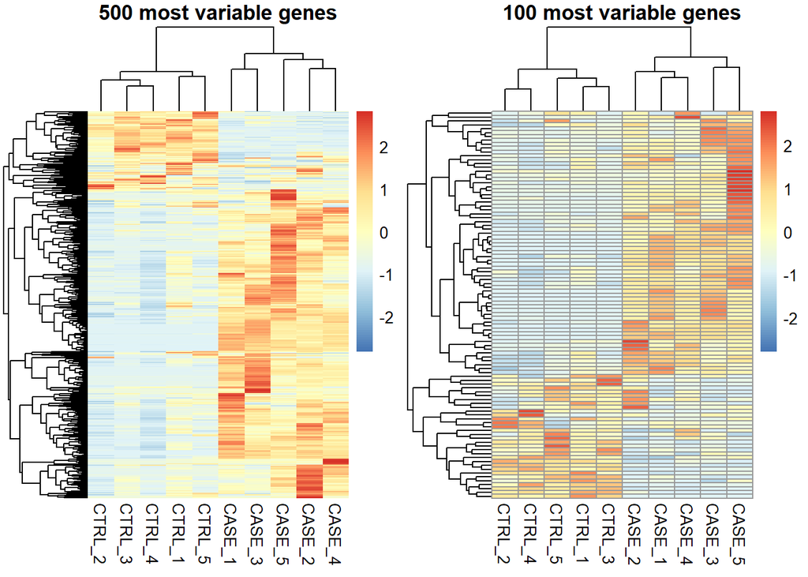

```r
V <- apply(tpm, 1, var)

selectedGenes_V <- names(V[order(V, decreasing = TRUE)][1:500])

heatmap_500 <- pheatmap(tpm[selectedGenes_V,],
                        scale = 'row',
                        main = "500 most variable genes",
                        silent = TRUE,
                        show_rownames = FALSE)

selectedGenes_V100 <- names(V[order(V, decreasing = TRUE)][1:100])

heatmap_100 <- pheatmap(tpm[selectedGenes_V100,],
                        scale = 'row',
                        main = "100 most variable genes",
                        silent = TRUE,
                        show_rownames = FALSE)
```

3. Re-do the heatmaps setting the scale argument to none, and column. Compare the results with scale = ‘row’.

*Scaling is important! scaling by row means we scale the counts for each gene separately, so we can compare the specific gene’s expression levels between the samples.* *Scaling by columns means we scale the counts for each sample separately, which is not very informative as in each sample the genes are expressed in different scales, some having much more transcripts than others.*

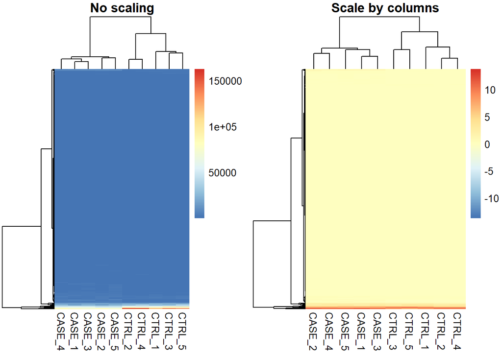

```r
selectedGenes_V <- names(V[order(V, decreasing = TRUE)][1:500])

heatmap_no_scale <- pheatmap(tpm[selectedGenes_V,],
                        scale = 'none',
                        main = "No scaling",
                        silent = TRUE,
                        show_rownames = FALSE)

heatmap_col_sacle <- pheatmap(tpm[selectedGenes_V,],
                        scale = 'column',
                        main = "Scale by columns",
                        silent = TRUE,
                        show_rownames = FALSE)
```

4. Draw a correlation plot for the samples depicting the sample differences as ‘ellipses’, drawing only the upper end of the matrix, and order samples by hierarchical clustering results based on average linkage clustering method.

```r
correlationMatrix <- cor(tpm)
correlationMatrix
```

```
##           CASE_1    CASE_2    CASE_3    CASE_4    CASE_5    CTRL_1    CTRL_2
## CASE_1 1.0000000 0.9924606 0.9959093 0.9934098 0.9901892 0.9594011 0.9635760
## CASE_2 0.9924606 1.0000000 0.9887290 0.9935931 0.9898379 0.9725646 0.9793835
## CASE_3 0.9959093 0.9887290 1.0000000 0.9950905 0.9928878 0.9648812 0.9617747
## CASE_4 0.9934098 0.9935931 0.9950905 1.0000000 0.9922521 0.9739553 0.9748582
## CASE_5 0.9901892 0.9898379 0.9928878 0.9922521 1.0000000 0.9631663 0.9660868
## CTRL_1 0.9594011 0.9725646 0.9648812 0.9739553 0.9631663 1.0000000 0.9879862
## CTRL_2 0.9635760 0.9793835 0.9617747 0.9748582 0.9660868 0.9879862 1.0000000
## CTRL_3 0.9549607 0.9674813 0.9555745 0.9643073 0.9502160 0.9902278 0.9819794
## CTRL_4 0.9548669 0.9739136 0.9551676 0.9709639 0.9587173 0.9874452 0.9970251
## CTRL_5 0.9302553 0.9448425 0.9401090 0.9510741 0.9313136 0.9864399 0.9642249
##           CTRL_3    CTRL_4    CTRL_5
## CASE_1 0.9549607 0.9548669 0.9302553
## CASE_2 0.9674813 0.9739136 0.9448425
## CASE_3 0.9555745 0.9551676 0.9401090
## CASE_4 0.9643073 0.9709639 0.9510741
## CASE_5 0.9502160 0.9587173 0.9313136
## CTRL_1 0.9902278 0.9874452 0.9864399
## CTRL_2 0.9819794 0.9970251 0.9642249
## CTRL_3 1.0000000 0.9850769 0.9902712
## CTRL_4 0.9850769 1.0000000 0.9738649
## CTRL_5 0.9902712 0.9738649 1.0000000
```

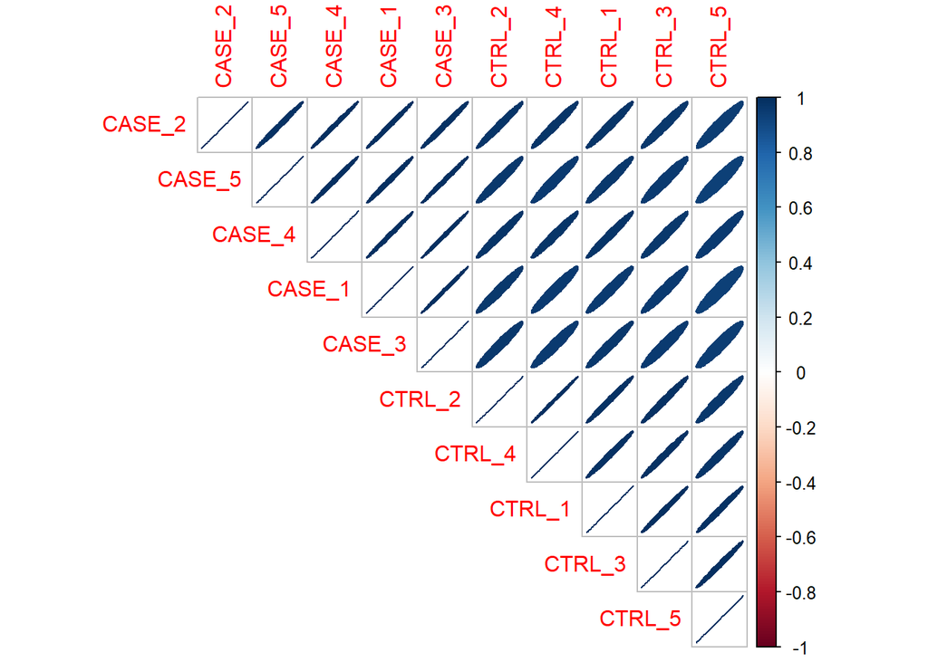

```r
corrplot(correlationMatrix,
         type = "upper",
         method = "ellipse",
         order = 'hclust',
         hclust.method = "average",
         number.cex = 0.7)
```

5. How else could the count matrix be subsetted to obtain quick and accurate clusters? Try selecting the top 100 genes that have the highest total expression in all samples and re-draw the cluster heatmaps and PCA plots.

```r
S <- apply(tpm, 1, sum)
selectedGenes_S <- names(S[order(S, decreasing = TRUE)][1:100])
```

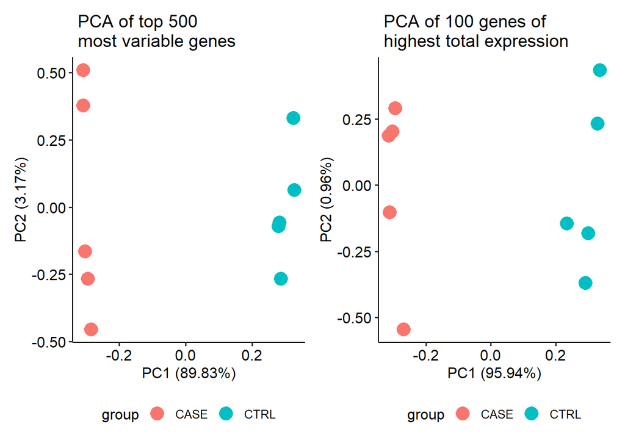

```r
M <- t(tpm[selectedGenes_S,])
M <- log2(M + 1)
pcaResults = prcomp(M)

PCA_S <- autoplot(pcaResults, data = metadata, colour = 'group', size = 5) +
  ggtitle(" PCA of 100 genes of \n highest total expression") +
  theme_pubr(legend = "bottom")

M <- t(tpm[selectedGenes_V,])
M <- log2(M + 1)
pcaResults = prcomp(M)
PCA_V <- autoplot(pcaResults, data = metadata, colour = 'group', size = 5)+
    ggtitle(" PCA of top 500 \n most variable genes") +
  theme_pubr(legend = "bottom")

PCA_V + PCA_S
```

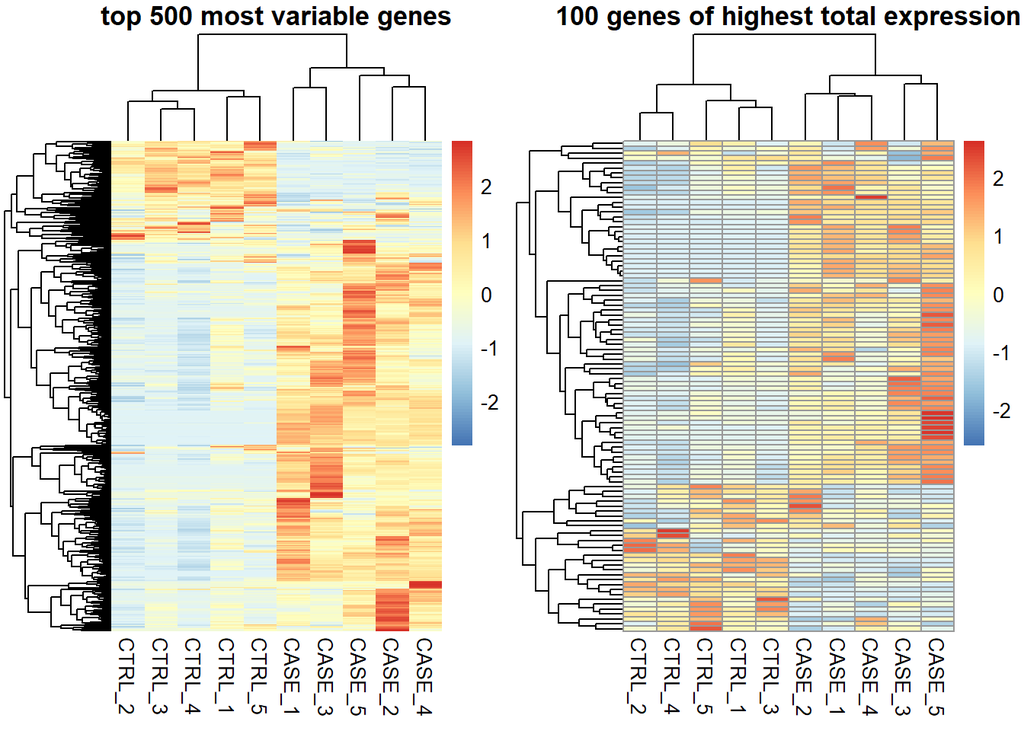

```r
heatmap_V <- pheatmap(tpm[selectedGenes_V,],
                        scale = 'row',
                        main = "top 500 most variable genes",
                        silent = TRUE,
                        show_rownames = FALSE)

heatmap_S <- pheatmap(tpm[selectedGenes_S,],
                        scale = 'row',
                        main = "100 genes of highest total expression",
                        silent = TRUE,
                        show_rownames = FALSE)
```

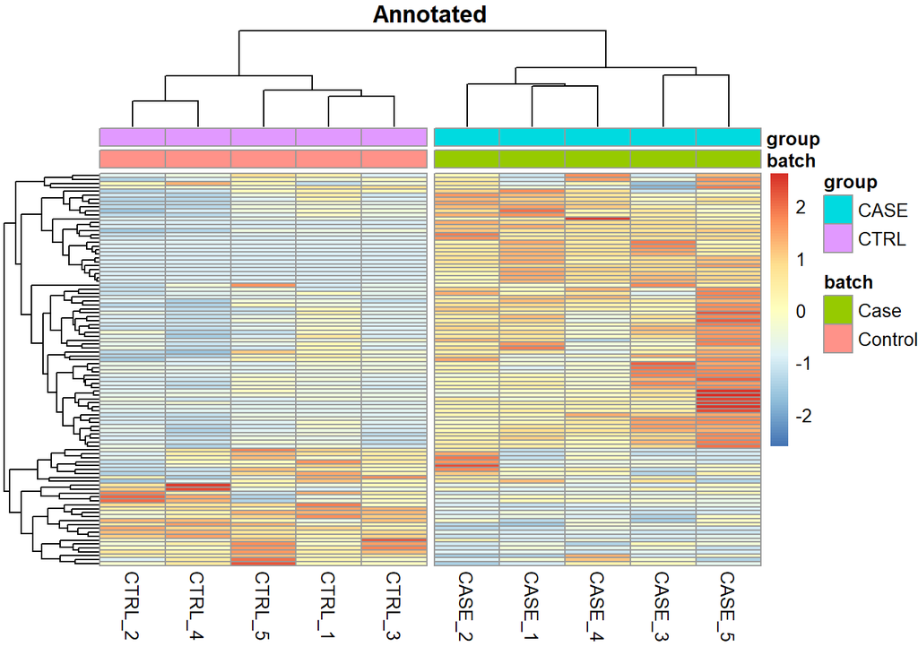

```r
metadata$batch <- "Control"

metadata$batch[metadata$group == "CASE"] <- "Case"

heatmap_annotated <- pheatmap(tpm[selectedGenes_S,],
                        scale = 'row',
                        main = "Annotated",
                        annotation_col = metadata[,c('batch','group')],
                        cutree_cols = 2,
                        show_rownames = FALSE)
```

7. Try making the heatmaps using all the genes in the count table, rather than sub-selecting. *It returns an error* `Error in hclust(d, method = method) : NA/NaN/Inf in foreign function call (arg 10)`  
   *We need to filter genes that have 0 reads across all samples*

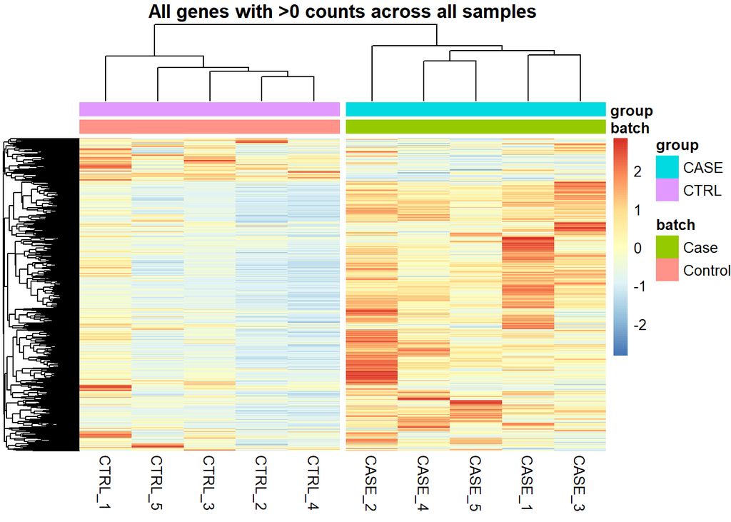

```r
tpm_filt <- as.data.frame(tpm) %>% filter(across(everything(.)) != 0)

heatmap_full <- pheatmap(tpm_filt,
                        scale = 'row',
                        main = "All genes with >0 counts across all samples",
                        annotation_col = metadata[,c('batch','group')],
                        cutree_cols = 2,
                        show_rownames = FALSE)
```

## Git and Github

8. Open Github account, and install git if it required as instructed in the following link: https://github. com/llendway/github_for_collaboration/blob/master/github_for_collaboration.md
9. Create a repository and commit and push the answers of this exercise and the next exercises through Rtudio (Please upload the answers to the exercises also to Moodle) .
10. Insert the link to your Github account here.

https://github.com/ShaQasso/GenomicDS_course